# Status and Green Purchases

*N* removed NAs: 5

*N* removed <18: 26

[output not shown]

[output not shown]

**Main analysis results**

**car:**  
χ<sup>2</sup>(1) = 1.34, *p* = .247

**cleaner:**  
χ<sup>2</sup>(1) = 2.18, *p* = .139

**dishwasher:**  
χ<sup>2</sup>(1) = 6.17, *p* = .013

# Status and Green Purchases

University of Sussex, Psychology

2020-04-27

# **Methods**

## Participants

|  | Age | Gender | Condition |
| --- | --- | --- | --- |
|  | Min. :19.00 | male :56 | control :59 |
|  | 1st Qu.:20.00 | female:44 | experimental:67 |
|  | Median :22.00 | other :26 | NA |
|  | Mean :21.92 | NA | NA |
|  | 3rd Qu.:23.00 | NA | NA |
|  | Max. :29.00 | NA | NA |

<sup>a</sup> **Figure 1. Summay table of the participants**  
<sup>b</sup> The removed data is not shown in this table

## Design

This study is a replication of Griskevicius, Tybur and Van den Bergh (2010) which hypothesised that status is the motivation to purchase green products. As the natural selection (Hamilton, 1964) suggested that species only benefit the same kin and social allies. While green products are seen as the products with lower capability and efficiency but eco-friendly compared to the luxurious products, which have better functionality and more efficient. Therefore, purchasing green products is an altruistic act, sacrificing oneself to benefit others. As a result, buying green products is contradictory to the theory of natural selection. So, we question that status is the motivation triggering the purchase of green products.

In the beginning of the study, each participant in the experimental group received a status story to elicit status motive. The story encouraged participants to imagine themselves as a person who got a high status job in the workplace filled with posh furniture. And there were also some same sex colleagues worked for them, promoting hierarchical composition. While in the control story, it was about going out to a music concert with our friend, purely emphasizing the interaction with our friend without any status motives. Both stories were captured from the original study (Griskevicius, Tybur & Van den Bergh, 2010).

After driving the status motives out, each participant needed to complete a computer task individually. Participants were required to imagine themselves shopping in a mall and buy three products such as car, cleaner and dishwasher. While each product had a luxurious version and a proenvironmental version, both were manufactured by the same company but differentiate in features. For example, the luxurious version of the car had bigger horse power, faster top speed and a streamline design. In contrast, the proenvironmental version was less powerful with ordinary design and the major function is zero emission and quiet. Cleaner and disherwasher were in the condition similar to car.

In terms of the design, this study hypotheses that there are more participants in the experimental group than the control group choosing green products. Participants needed to choose their preference of three different products on a multiple choices questionnaire. Higher number of the products chosen shows a stronger preference, vice versa. The independent variables are the content of the stories and the types of the products while the dependent variable is the number of products of the different types being chosen. For showing the relationship betwenn variables, chi-square test is used on three products.

It is predicted status motive activated participants choose more green products than the control groups. As according to the costly signal theory (Grafen, 1990; Zahavi, 1975), it suggests that the altruistic behaviour of sacrificing oneself resources to help others can show the wealthiness and ability to help, increasing the status. Therefore, after the status motive is activated, people are tend to purchase green products to promote the status level.

# **Results**

The following section shows the relationship of the purchasing preferences between the control group and the experimental group. And the analyses of three different products are performed separately. For showing the frequency of choosing each product, a bar graph is used to indicate the discrepancy between two groups while a chi-square test is used to demonstrate the independence and relationship of green products and the exterimental group.

## Figure 2. Control and Experimental

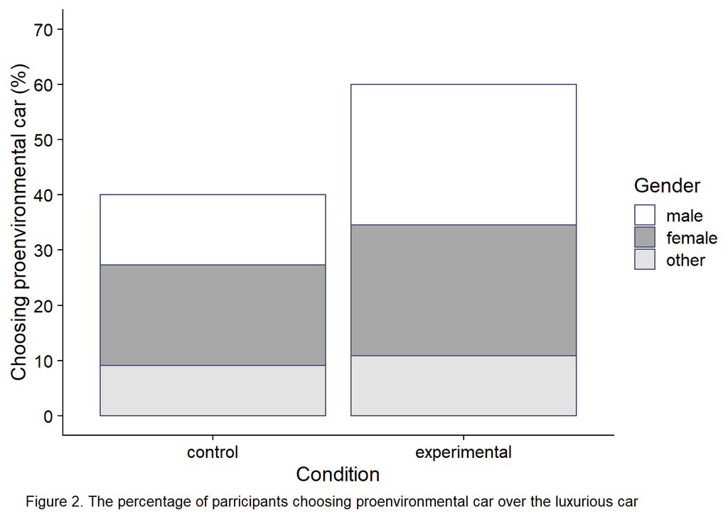

## Figure 3. Luxurious car and Proenvironmental car

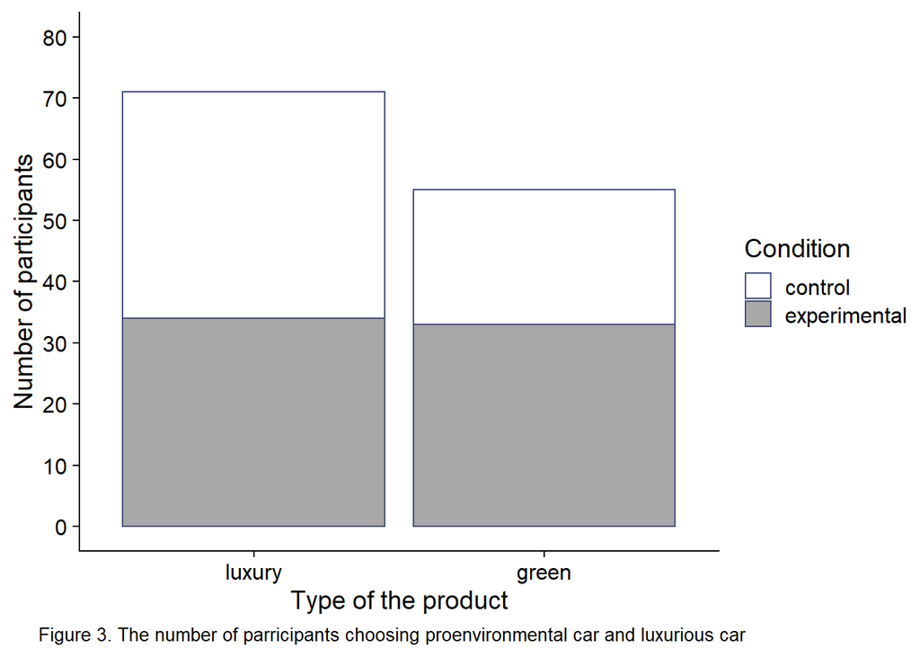

Figure 2 shows that 60% of the participants chose to purchase the proenvironmental car were in the experimental group while only 40% were from the control group. And male and female had a similar ratio in the experimental group while there were more female than male in the control group. Whereas comparing green and luxurious car, figure 3 clearly shows that there were more participants chose a luxurious car. Meanwhile, the status story is not effective to kindle buying the green version as there are a similar number of experimental participants on both luxurious and green types.

## Figure 4. Control and Experimental

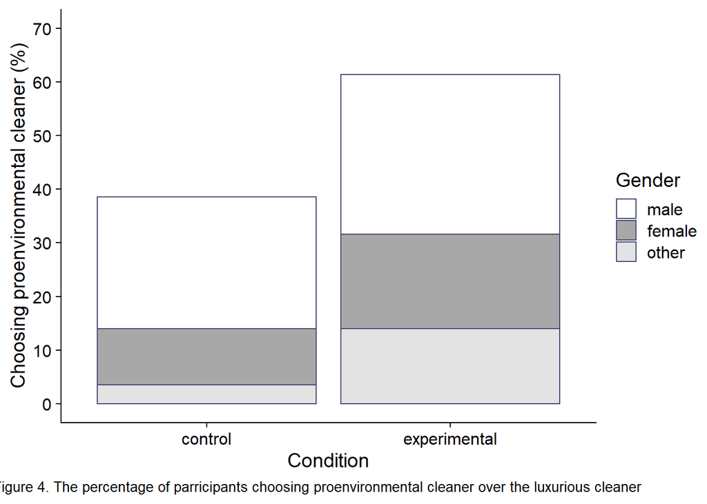

## Figure 5. Luxurious cleaner and Proenvironmental cleaner

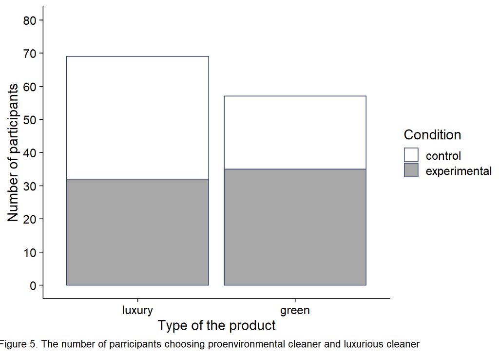

Figure 4 shows the proportion of buying green cleaner, there are more than 60% of the participants were in the experimental group and the rest were in the control group. There were more male than female in both the experimental and control group. And figure 5 indicates there were more participants who chose to buy the luxurious version than the green version overall. While the status motive showed a small effect since there were slightly more experimental participants choosing green cleaner than luxurious cleaner.

## Figure 6. Control and Experimental

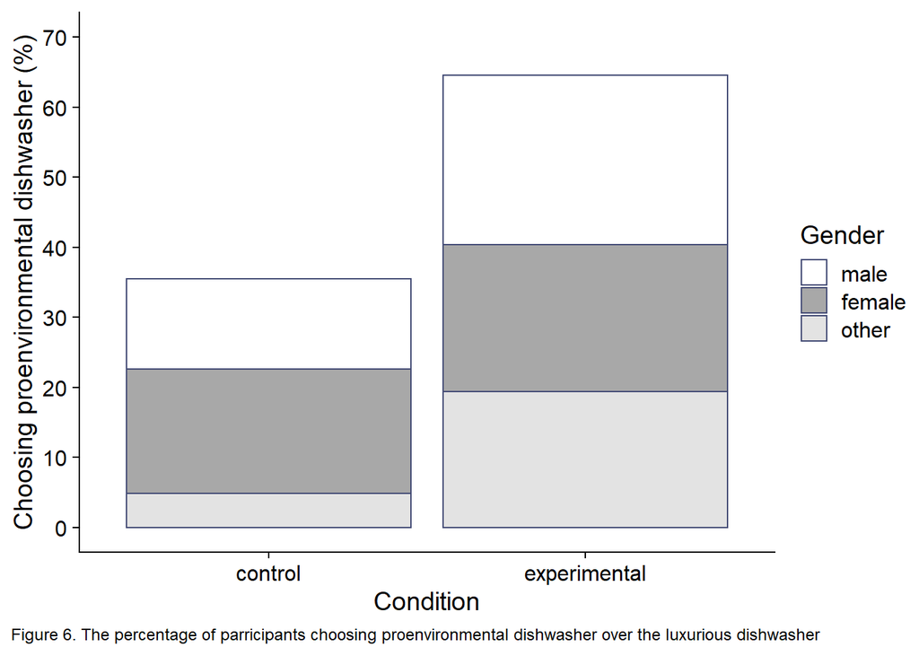

## Figure 7. Luxurious dishwasher and Proenvironmental dishwasher

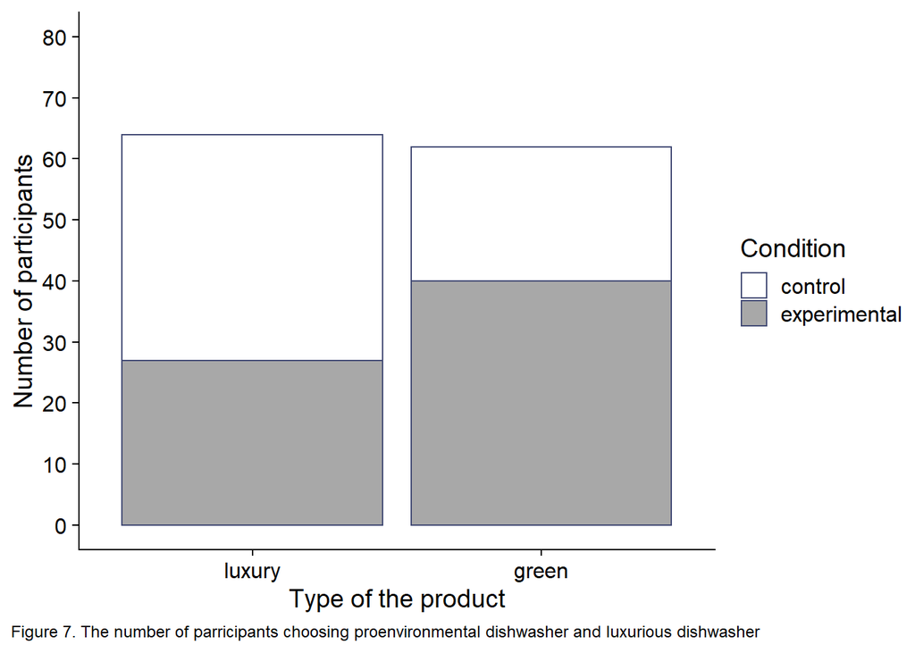

Figure 6 displays the participants choosing the proenvironmental dishwasher nearly 65% were in the experimental group while close to 35% of the participants were in the control group. And the number of male and female were relatively even in the experimental group while female were more than male in the control group. In general, figure 7 showed there were more participants who chose the luxurious version of dishwasher. But more experimental participants chose green dishwasher than the luxurious version.

# **Discussion**

The research questioned does status motive drive people to purchase green products. And we hypothesized the experimental group with status motive activated chose more green products than the control group. But the findings show there is no relationship between proenvironmental car and cleaner with the experimental group participants. The data are only strong enough to support status motives drive people to buy proenvironmental dishwashers. Therefore, the results explicate the kinds of the products is substantial and exaggerate the theory of natural selection natural selection (Hamilton, 1964) that people concern more about their own needs rather than benefit others.

## **Limitations and future research**

The current study and the original study (Griskevicius, Tybur and Van den Bergh, 2010) are also a computer based study, not involving any actual purchase in real life, which have validity issue from the findings as people may not react the same as they behave in the questionnaires. Also, there are confounding variables in the study. The knowledge concerning environmental conservation is of importance (Darnall, Ponting and Vazquez-Brust, 2012; Lee, 2017). If the experimental group are not familiar with green purchase habits, the status story is not effective to lead so.

In the future studies, it is suggested that the researchers randomly select the same number of male and female participants to eliminate the difference of preference between gender. Also, the selection of the products should focus on the exposure to the participants for instance computer, mobile phone and foods for young age group of participants. Furthermore, observational field study is a good advancement for the future study as it includes actual purchase and different group age of people.

# **References**

Darnall, N., Ponting, C. and Vazquez-Brust, D. (2012). Why consumers buy green. 10.13140/2.1.2610.2727.

Grafen, A. (1990). Biological signals as handicaps. Journal of Theoretical Biology, 144, 517–546.

Griskevicius, V., Tybur, J., & Van den Bergh, B. (2010). Going green to be seen: Status, reputation, and conspicuous conservation. Journal of Personality and Social Psychology, 98(3), 392-404. doi: 10.1037/a0017346

Hamilton, W. D. (1964). The genetical evolution of social behavior, I, II. Journal of Theoretical Biology, 7, 1–52.

Kasumovic, M. and Kuznekoff, J. (2015). Insights into Sexism: Male Status and Performance Moderates Female-Directed Hostile and Amicable Behaviour. PLoS ONE. 10. 1-14. 10.1371/journal.pone.0131613.

Lee, Y. (2017). A Comparative Study of Green Purchase Intention between Korean and Chinese Consumers: The Moderating Role of Collectivism. Sustainability. 9. 1930. 10.3390/su9101930.

Zahavi, A. (1975). Mate selection: Selection for a handicap. Journal of Theoretical Biology, 53, 205–214.